# Project1

```python
import pandas as pd
import seaborn as sns
import matplotlib.pyplot as plt
sns.set(color_codes=True)
%matplotlib inline
```

```python
import sys
!{sys.executable} -m pip install pandas-profiling[notebook]
import pandas_profiling
```

```python
import warnings
warnings.filterwarnings('ignore')
```

```python
Cardio=pd.read_csv('CardioGoodFitness.csv')#save the data as Cardio
```

Let's start with a general multivariant evaluation

```python
pandas_profiling.ProfileReport(Cardio) #a profile of the data
```

[interactive chart not shown]

It appears that there are good correlations between age and income (looks to be about 0.5) and education and income (0.75 or so) Miles, usage, and fitness all look to have positive relations with eachother Other more minor relations appear to exist let's look at the basic info of the dataste in another way

```python
Cardio.info()#see missing info, size, names, and datatyes
```

```
<class 'pandas.core.frame.DataFrame'>
RangeIndex: 180 entries, 0 to 179
Data columns (total 9 columns):
 #   Column         Non-Null Count  Dtype
---  ------         --------------  -----
 0   Product        180 non-null    object
 1   Age            180 non-null    int64
 2   Gender         180 non-null    object
 3   Education      180 non-null    int64
 4   MaritalStatus  180 non-null    object
 5   Usage          180 non-null    int64
 6   Fitness        180 non-null    int64
 7   Income         180 non-null    int64
 8   Miles          180 non-null    int64
dtypes: int64(6), object(3)
memory usage: 12.8+ KB
```

```python
Cardio.describe()
```

|  | Age | Education | Usage | Fitness | Income | Miles |
| --- | --- | --- | --- | --- | --- | --- |
| count | 180.000000 | 180.000000 | 180.000000 | 180.000000 | 180.000000 | 180.000000 |
| mean | 28.788889 | 15.572222 | 3.455556 | 3.311111 | 53719.577778 | 103.194444 |
| std | 6.943498 | 1.617055 | 1.084797 | 0.958869 | 16506.684226 | 51.863605 |
| min | 18.000000 | 12.000000 | 2.000000 | 1.000000 | 29562.000000 | 21.000000 |
| 25% | 24.000000 | 14.000000 | 3.000000 | 3.000000 | 44058.750000 | 66.000000 |
| 50% | 26.000000 | 16.000000 | 3.000000 | 3.000000 | 50596.500000 | 94.000000 |
| 75% | 33.000000 | 16.000000 | 4.000000 | 4.000000 | 58668.000000 | 114.750000 |
| max | 50.000000 | 21.000000 | 7.000000 | 5.000000 | 104581.000000 | 360.000000 |

our data does not seem to hav missing info Now let's visualize our data, Product gender, and Marital status will be count plots, the other dist plots

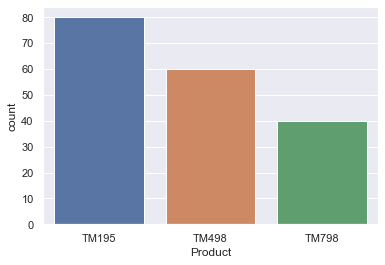

```python
sns.countplot(Cardio['Product'])
plt.show()
```

TM195 is the most popular

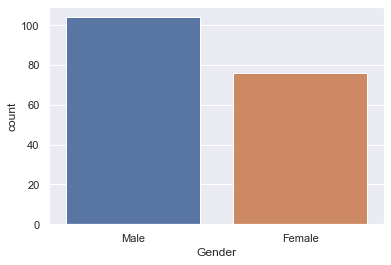

```python
sns.countplot(Cardio['Gender'])
plt.show()
```

Men tend to use our product more but women are still important

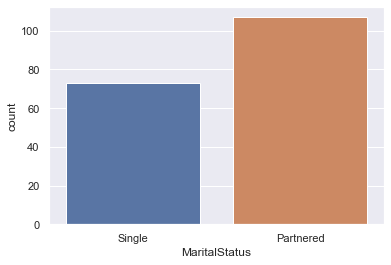

```python
sns.countplot(Cardio['MaritalStatus'])
plt.show()
```

A majority of our customers are married

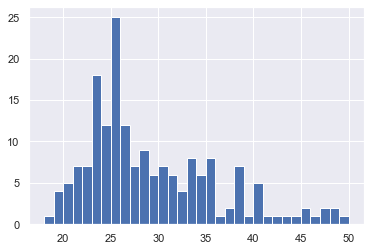

```python
plt.hist(Cardio['Age'],32)#18-50 is 32 year spread
plt.show()
```

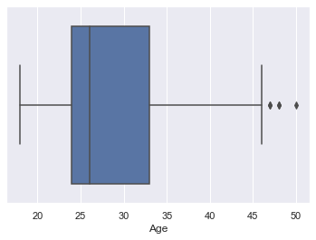

```python
sns.boxplot(Cardio['Age'])
plt.show()
```

Most of our clients are in their 20s

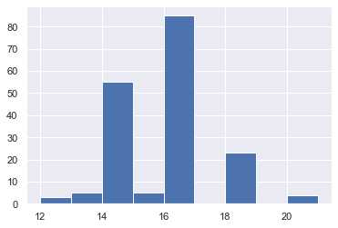

```python
plt.hist(Cardio['Education'],9)#12-21 years is a 9 years spread
plt.show()
```

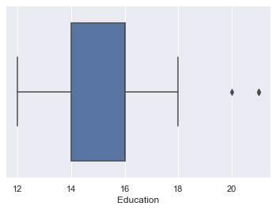

```python
sns.boxplot(Cardio['Education'])
plt.show()
```

Most of our clients have 14 (high school) 16(associates) or 18 (bachelors) years of education with outliers having more

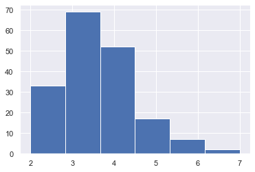

```python
plt.hist(Cardio['Usage'],6)#2 through 7 dats a week is 6 possible usage numbers
plt.show()
```

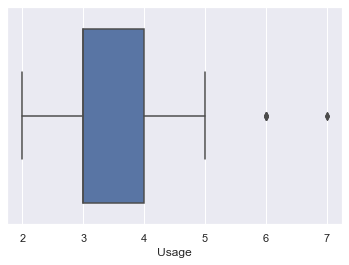

```python
sns.boxplot(Cardio['Usage'])
plt.show()
```

Most work out 3-4 times a week 6 and 7 seem to be outliers

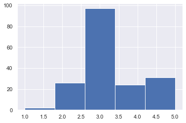

```python
plt.hist(Cardio['Fitness'],5)#1-5
plt.show()
```

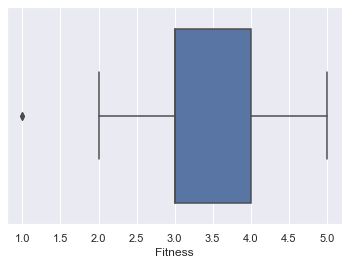

```python
sns.boxplot(Cardio['Fitness'])
plt.show()
```

Most of our clients are average with a larger number being above average than below and indeed the people at level 1 are outliers

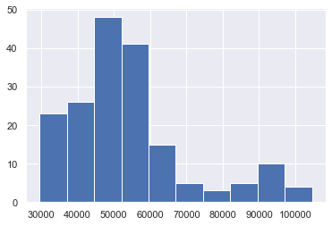

```python
plt.hist(Cardio['Income'],10)#lets get a general idea
plt.show()
```

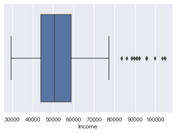

```python
sns.boxplot(Cardio['Income'])
plt.show()
```

Most are around 50,000-60,000 well above average in us (30,000) wirh a few being wealthier and non being below the us average. Anyone abboe 75,000 is an outlier, this has many outliers

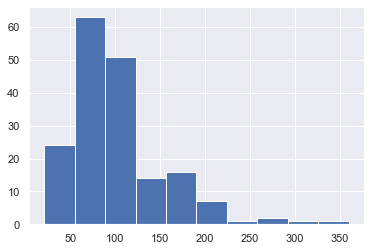

```python
plt.hist(Cardio['Miles'],10)#lets get a general idea
plt.show()
```

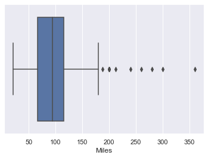

```python
sns.boxplot(Cardio['Miles'])
plt.show()
```

Our clients seem motivated with most running atleast 50 miles. Some are much higher and some are lower Outliers above 175

Lets do an analysis of age and income/usage to see which age uses the prduct most and has the most disposable income

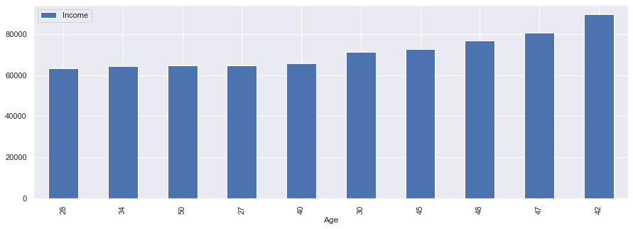

```python
Cardio.groupby(by=['Age'])['Income'].mean().reset_index().sort_values(['Income']).tail(10).plot(x='Age', y='Income', kind='bar', figsize=(15,5))
plt.show()
```

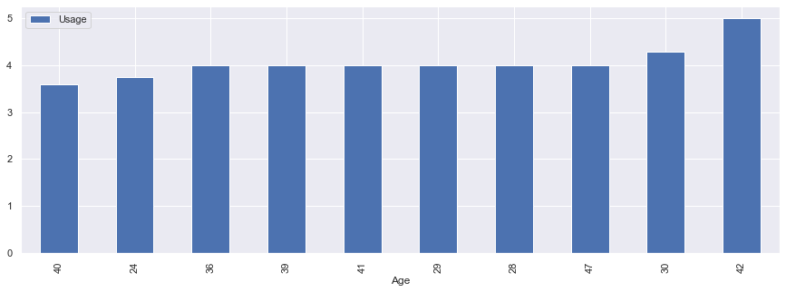

```python
Cardio.groupby(by=['Age'])['Usage'].mean().reset_index().sort_values(['Usage']).tail(10).plot(x='Age', y='Usage', kind='bar', figsize=(15,5))
plt.show()
```

It appears that young adults (27-30) and middle age adults (40-48) make the largest amount of income Similiarly, young adults (24-30) and middle age adults (40-47) also use the treadmill most This should mean that we should ofcus efforts on these two groups. We can now look at the opposite, which age groups are likely to be the smallest contribution

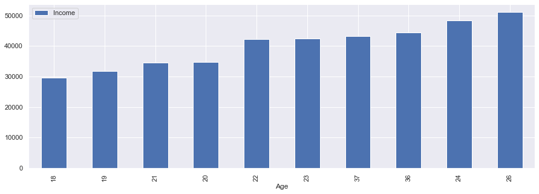

```python
Cardio.groupby(by=['Age'])['Income'].mean().reset_index().sort_values(['Income']).head(10).plot(x='Age', y='Income', kind='bar', figsize=(15,5))
plt.show()
```

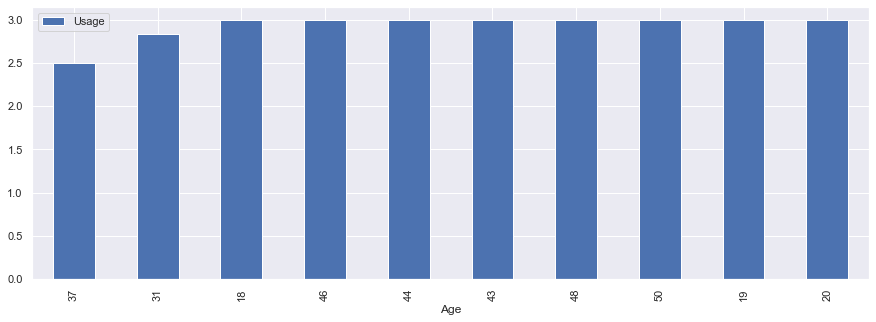

```python
Cardio.groupby(by=['Age'])['Usage'].mean().reset_index().sort_values(['Usage']).head(10).plot(x='Age', y='Usage', kind='bar', figsize=(15,5))
plt.show()
```

It seems that very young adults (18-26) and older but not middle age adults (36-37) have the lowest income The least usage appears amongst very young adults (18-20) older but not middle age adults (37) and older middle aged adults (43-50) but this difference seems to be minor in both cases. So while there may be minor age difference in usage, we may not want to use it as a major targetting indicator

We know mor emen use than women, now lets look at their ncome and usage

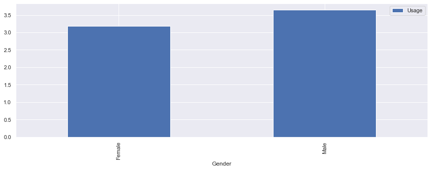

```python
Cardio.groupby(by=['Gender'])['Usage'].mean().reset_index().sort_values(['Usage']).head(10).plot(x='Gender', y='Usage', kind='bar', figsize=(15,5))
plt.show()
```

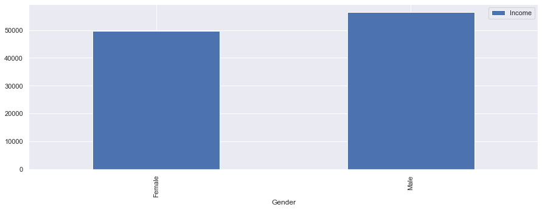

```python
Cardio.groupby(by=['Gender'])['Income'].mean().reset_index().sort_values(['Income']).tail(10).plot(x='Gender', y='Income', kind='bar', figsize=(15,5))
plt.show()
```

Men tend to use the product a little more and make a little more Now lets look at fitness and also see if it has any interaction with gender or age